# Bolas_Lab7

Ellie Bolas, GEO200CN, spring 2017

### Elise Mini-Lecture

x=longitude y=latitude

-Using euclidean distance to find distance between lat long points, but this is wrong. euclidean should not be used for lat long because euclidean distance is supposed to be used on a sphere, not a flat plane. but, here we use this because of the function we will use

cols <-apply(D,1,order) <-figure out what this code does. This code touches on nearest neighbors and indexes apply on a distance matrix over the rows using the function “order”

# Lab 7: Distance + Spatial Influence

In this lab you will continue to practice point pattern analysis with R. If the concepts you are working with feel unclear or unfamiliar that’s a good hint that you might want to re-review Chapt 5+6 of OSU and your lecture notes.

Start by reading and following along with the Distance section, and the first three subsections (Adjacency, Two Nearest Neighbors, Weight Matrix) of the Spatial Influence section of Chapt 2. Scale and Distance in the Spatial Data Analysis on RSpatial. Then respond to the questions below. [see the lab handout for greater details]

# 1. Distance

[http://rspatial.org/analysis/rst/2-scale_distance.html#distance] ###a) [Question 4 in the text] Show R code to make a cluster dendogram summarizing the distances between these six sites, and plot it. See ?hclust [Remember dendogram are a tree of branching diagram that illustrates clustering or similarity]

```r
A <- c(40, 43)
B <- c(101, 1)
C <- c(111, 54)
D <- c(104, 65)
E <- c(60, 22)
F <- c(20, 2)
pts <- rbind(A, B, C, D, E, F)
pts
```

```
##   [,1] [,2]
## A   40   43
## B  101    1
## C  111   54
## D  104   65
## E   60   22
## F   20    2
```

```r
dis<- dist(pts)
D <- as.matrix(dis)
round(D)
```

```
##    A  B   C   D  E   F
## A  0 74  72  68 29  46
## B 74  0  54  64 46  81
## C 72 54   0  13 60 105
## D 68 64  13   0 62 105
## E 29 46  60  62  0  45
## F 46 81 105 105 45   0
```

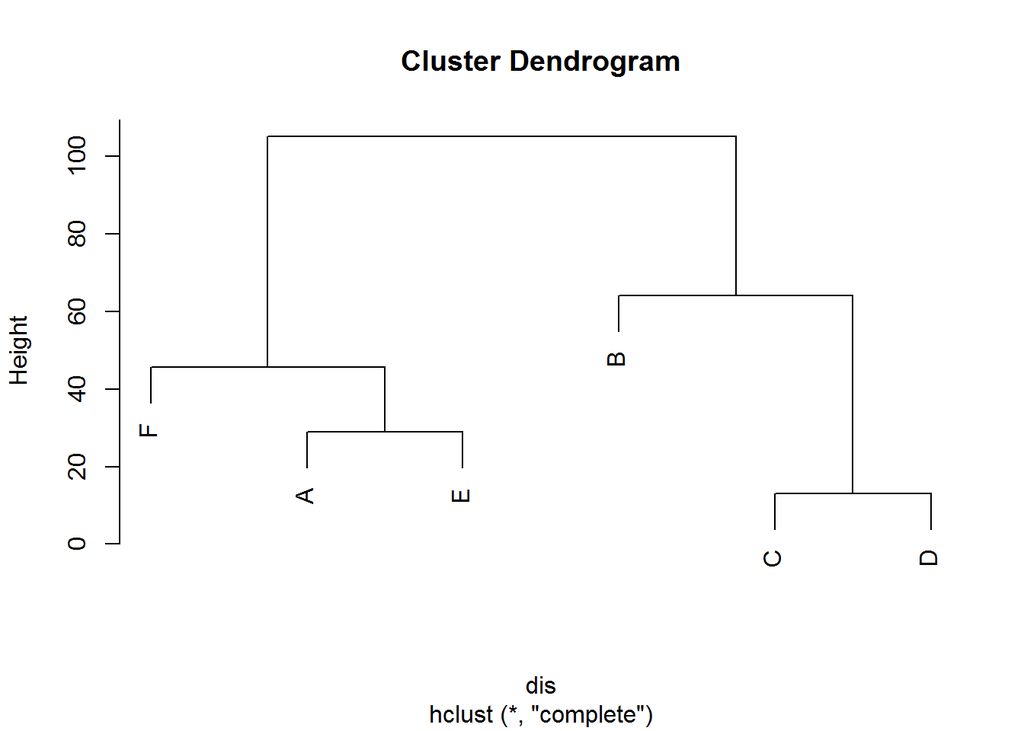

```r
#cluster dendogram
hc <- hclust(dis, method = "complete", members = NULL)
plot(hc)
```

### b) [Question 5 in the text] What is the unit of the values in “gdis”? See ?pointDistance

-What if pts were in long/lat. Can’t use dist function. Intead, use pointDistance function from the raster package, which calculates the geographic distance in a WGS ellipsoid

-Answer: distance is given as meters or map-units, depending on what the input is. I think here it’s meters.

```r
library(raster)
gdis <- pointDistance(pts, lonlat=TRUE) #here we are pretending that the points are in lat long and finding the distance between them
gdis
```

```
##         [,1]    [,2]    [,3]    [,4]    [,5] [,6]
## [1,]       0      NA      NA      NA      NA   NA
## [2,] 7614198       0      NA      NA      NA   NA
## [3,] 5155577 5946748       0      NA      NA   NA
## [4,] 4581656 7104895 1286094       0      NA   NA
## [5,] 2976166 5011592 5536367 5737063       0   NA
## [6,] 4957298 9013726 9894640 9521864 4859627    0
```

# 2.Spatial Influence [http://rspatial.org/analysis/rst/2-scale_distance.html#spatial-influence]

### a) In preparing the two nearest neighbors matrix, why do you select columns 2 and 3, and not column 1?

```r
#Adjacency
#take D, which is a matrix of all the distances, then asks which are the nearest neighbors (those within 50 m, and put them in a)
a <-  D < 50
a #this tells us which of these distances are under 50 m
```

```
##       A     B     C     D     E     F
## A  TRUE FALSE FALSE FALSE  TRUE  TRUE
## B FALSE  TRUE FALSE FALSE  TRUE FALSE
## C FALSE FALSE  TRUE  TRUE FALSE FALSE
## D FALSE FALSE  TRUE  TRUE FALSE FALSE
## E  TRUE  TRUE FALSE FALSE  TRUE  TRUE
## F  TRUE FALSE FALSE FALSE  TRUE  TRUE
```

```r
diag(a) <- NA #set diagonals to NAs
Adj50 <- a * 1 #set true/false to 1/0
Adj50
```

```
##    A  B  C  D  E  F
## A NA  0  0  0  1  1
## B  0 NA  0  0  1  0
## C  0  0 NA  1  0  0
## D  0  0  1 NA  0  0
## E  1  1  0  0 NA  1
## F  1  0  0  0  1 NA
```

```r
cols <- apply(D, 1, order) #apply the function "order" to matrix D over rows (1)
# we need to transpose the result
cols <- t(cols)
cols2 <- cols[, 1:3]
cols2
```

```
##   [,1] [,2] [,3]
## A    1    5    6
## B    2    5    3
## C    3    4    2
## D    4    3    5
## E    5    1    6
## F    6    5    1
```

```r
cols3 <- cols[, 2:3]
cols3
```

```
##   [,1] [,2]
## A    5    6
## B    5    3
## C    4    2
## D    3    5
## E    1    6
## F    5    1
```

Answer: This matrix shows you the two neighbors closest to each element. For example, for A, the 5th and 6th (E & F) are closest. No need to include the first column, because that just tells you that A is closest to A, B is closest to B, and so on. A is not it’s own neighbor, so we leave it out.

# 3. Distance and Weight Matrix UCD Places

### a) Using the same UCD places we used in Lab4 [UCplaces.csv] you will calculate a binary distance matrix that defines neighbors as places closer than 500 meters.

### b) Which places are defined as neighbors to Hunt Hall?

Hint: if the matrix output from ?pointDistance only returns half the matrix you can calculate the symmetrical matrix fairly simply with the forceSymmetric function in the Matrix package. See ?forceSymmetric for details

```r
datapath <- 'C:/Users/ebola/Google Drive/Git/GEO200CN/data/'
UCplaces <- read.csv(file.path(datapath, "UCplaces.csv"))
UCplaces
```

```
##             names      lat      long
## 1       Hunt Hall 38.54333 -121.7503
## 2 MU coffee house 38.54167 -121.7500
## 3  Mondavi Center 38.53444 -121.7486
## 4            Silo 38.53861 -121.7531
## 5       Arboretum 38.53833 -121.7469
```

```r
#UC<- UCplaces[,2:3]
#UC
#the problem is that the data reads in as latlon, I need the order of the columns reversed
UC<- UCplaces[,3:2]
UC
```

```
##        long      lat
## 1 -121.7503 38.54333
## 2 -121.7500 38.54167
## 3 -121.7486 38.53444
## 4 -121.7531 38.53861
## 5 -121.7469 38.53833
```

```r
UCdis <- pointDistance(UC, lonlat=TRUE)
UCdis
```

```
##          [,1]     [,2]     [,3]     [,4] [,5]
## [1,]   0.0000       NA       NA       NA   NA
## [2,] 186.1181   0.0000       NA       NA   NA
## [3,] 997.9178 811.8072   0.0000       NA   NA
## [4,] 578.0284 434.0847 606.8049   0.0000   NA
## [5,] 629.2293 458.8156 456.5462 541.4482    0
```

```r
#neighbors within 500m
b <- UCdis < 500
b
```

```
##       [,1]  [,2]  [,3]  [,4] [,5]
## [1,]  TRUE    NA    NA    NA   NA
## [2,]  TRUE  TRUE    NA    NA   NA
## [3,] FALSE FALSE  TRUE    NA   NA
## [4,] FALSE  TRUE FALSE  TRUE   NA
## [5,] FALSE  TRUE  TRUE FALSE TRUE
```

```r
#make it binary
diag(b) <- NA
Adj500 <- b * 1
Adj500
```

```
##      [,1] [,2] [,3] [,4] [,5]
## [1,]   NA   NA   NA   NA   NA
## [2,]    1   NA   NA   NA   NA
## [3,]    0    0   NA   NA   NA
## [4,]    0    1    0   NA   NA
## [5,]    0    1    1    0   NA
```

```r
library(Matrix)
symAdj500 <- forceSymmetric(Adj500, "L")
symAdj500
```

```
## 5 x 5 Matrix of class "dsyMatrix"
##      [,1] [,2] [,3] [,4] [,5]
## [1,]   NA    1    0    0    0
## [2,]    1   NA    0    1    1
## [3,]    0    0   NA    0    1
## [4,]    0    1    0   NA    0
## [5,]    0    1    1    0   NA
```

Answer: Neighbors of Hunt Hall: Hunt hall is 1, it’s nearest neighbor (within 500 m) is 2, MU Coffee House.

### Bonus) Calculate a continuous value matrix for the same data, with distances measured in meters, and where rows sum to 1.

### Spatial Weights Matrix

The smaller the number, the farther away something is.

```r
UCdis
```

```
##          [,1]     [,2]     [,3]     [,4] [,5]
## [1,]   0.0000       NA       NA       NA   NA
## [2,] 186.1181   0.0000       NA       NA   NA
## [3,] 997.9178 811.8072   0.0000       NA   NA
## [4,] 578.0284 434.0847 606.8049   0.0000   NA
## [5,] 629.2293 458.8156 456.5462 541.4482    0
```

```r
D <- forceSymmetric(UCdis, "L")
D
```

```
## 5 x 5 Matrix of class "dsyMatrix"
##          [,1]     [,2]     [,3]     [,4]     [,5]
## [1,]   0.0000 186.1181 997.9178 578.0284 629.2293
## [2,] 186.1181   0.0000 811.8072 434.0847 458.8156
## [3,] 997.9178 811.8072   0.0000 606.8049 456.5462
## [4,] 578.0284 434.0847 606.8049   0.0000 541.4482
## [5,] 629.2293 458.8156 456.5462 541.4482   0.0000
```

```r
W <- 1 / D
round(W, 4)
```

```
## 5 x 5 Matrix of class "dsyMatrix"
##        [,1]   [,2]   [,3]   [,4]   [,5]
## [1,]    Inf 0.0054 0.0010 0.0017 0.0016
## [2,] 0.0054    Inf 0.0012 0.0023 0.0022
## [3,] 0.0010 0.0012    Inf 0.0016 0.0022
## [4,] 0.0017 0.0023 0.0016    Inf 0.0018
## [5,] 0.0016 0.0022 0.0022 0.0018    Inf
```

```r
W[!is.finite(W)] <- NA #get's rid of Inf values. these happened bc 1/0 = inf

#calculate row totals
rtot <- rowSums(W, na.rm=TRUE)
rtot
```

```
## [1] 0.009694284 0.011087975 0.006072241 0.007528592 0.007806028
```

```r
#normalize the rows by making them equal to 1
W2 <- W / rtot
rowSums(W2, na.rm=TRUE)
```

```
## [1] 1 1 1 1 1
```

```r
W2 #tis is a weighted spatial matrix (by row)
```

```
## 5 x 5 Matrix of class "dgeMatrix"
##           [,1]      [,2]      [,3]      [,4]      [,5]
## [1,]        NA 0.5542372 0.1033688 0.1784576 0.1639364
## [2,] 0.4845730        NA 0.1110951 0.2077654 0.1965665
## [3,] 0.1650275 0.2028608        NA 0.2713951 0.3607167
## [4,] 0.2297932 0.3059932 0.2188957        NA 0.2453180
## [5,] 0.2035921 0.2792105 0.2805984 0.2365990        NA
```

Upload to smartsite an Rmarkdown and HTML file.

Due: Wednesday, May 3, 9a